# uday ML & AI 1038804 final

## Business Problem

```
The Centers for Disease Control & Prevention (CDC) seek to strengthen public health surveillance & lower the incident of diabetes through data-driven decision-making. Diabetes is an escalating public health emergency that leads to serious complications like cardiovascular disorder, kidney failure, & amputations. The primary issue is to foresee a persons risk of developing diabetes based on lifestyle behaviours, medical history & demographic characteristics.
```

## Importance

```
>For public health agencies (CDC) enables evidence–based policymaking & resource allocation to populations at risk
>For healthcare providers facilities timely intervention & personalized therapeutic strategies.
>Insurance & Employers assists in health risk appraisal, lowering medical expenses & implementing wellness initiatives.
```

## Data collection strategy

```
>Using Available Datasets: Utilize CDC’s publicly accessible dataset of diabetes health indicators for analysis.
>Supplementary Data sources: Incorporate electronic health records, surveys & wearable device data to provide depth.

https://www.cdc.gov/brfss/
https://www.kaggle.com/datasets/abdelazizsami/cdc-diabetes-health-indicators/data
```

## Defining the problem as a Machine learning exercise

### This is a supervised classification problem, attempting to predict how probable a person will develop diabetes based on historical health data.

```
>Data Preprocessing.
>EDA (Exploratory Data Analysis).
>Feature Engineering.
>Model selection & Training.
>Model Evaluation.
>Saving the model.
```

```python
import numpy as np
import pandas as pd
import seaborn as sns
import matplotlib.pyplot as plt
from sklearn.preprocessing import scale, StandardScaler
from sklearn.model_selection import train_test_split, RandomizedSearchCV, cross_val_score
from sklearn.metrics import confusion_matrix, accuracy_score, roc_auc_score, roc_curve, classification_report
from sklearn.tree import DecisionTreeClassifier
from sklearn.ensemble import RandomForestClassifier, GradientBoostingClassifier
from sklearn.model_selection import KFold
import warnings
warnings.simplefilter(action='ignore')
```

```python
df = pd.read_csv(r"C:\Users\91951\Downloads\diabetes_health_indicator.csv")
pd.set_option('display.max_columns', None)
df.head()
```

|  | Diabetes_012 | HighBP | HighChol | CholCheck | BMI | Smoker | Stroke | HeartDiseaseorAttack | PhysActivity | Fruits | Veggies | HvyAlcoholConsump | AnyHealthcare | NoDocbcCost | GenHlth | MentHlth | PhysHlth | DiffWalk | Sex | Age | Education | Income |
| --- | --- | --- | --- | --- | --- | --- | --- | --- | --- | --- | --- | --- | --- | --- | --- | --- | --- | --- | --- | --- | --- | --- |
| 0 | 0.0 | 1.0 | 1.0 | 1.0 | 40.0 | 1.0 | 0.0 | 0.0 | 0.0 | 0.0 | 1.0 | 0.0 | 1.0 | 0.0 | 5.0 | 18.0 | 15.0 | 1.0 | 0.0 | 9.0 | 4.0 | 3.0 |
| 1 | 0.0 | 0.0 | 0.0 | 0.0 | 25.0 | 1.0 | 0.0 | 0.0 | 1.0 | 0.0 | 0.0 | 0.0 | 0.0 | 1.0 | 3.0 | 0.0 | 0.0 | 0.0 | 0.0 | 7.0 | 6.0 | 1.0 |
| 2 | 0.0 | 1.0 | 1.0 | 1.0 | 28.0 | 0.0 | 0.0 | 0.0 | 0.0 | 1.0 | 0.0 | 0.0 | 1.0 | 1.0 | 5.0 | 30.0 | 30.0 | 1.0 | 0.0 | 9.0 | 4.0 | 8.0 |
| 3 | 0.0 | 1.0 | 0.0 | 1.0 | 27.0 | 0.0 | 0.0 | 0.0 | 1.0 | 1.0 | 1.0 | 0.0 | 1.0 | 0.0 | 2.0 | 0.0 | 0.0 | 0.0 | 0.0 | 11.0 | 3.0 | 6.0 |
| 4 | 0.0 | 1.0 | 1.0 | 1.0 | 24.0 | 0.0 | 0.0 | 0.0 | 1.0 | 1.0 | 1.0 | 0.0 | 1.0 | 0.0 | 2.0 | 3.0 | 0.0 | 0.0 | 0.0 | 11.0 | 5.0 | 4.0 |

```python
df.info()
```

```
<class 'pandas.core.frame.DataFrame'>
RangeIndex: 253680 entries, 0 to 253679
Data columns (total 22 columns):
 #   Column                Non-Null Count   Dtype
---  ------                --------------   -----
 0   Diabetes_012          253680 non-null  float64
 1   HighBP                253680 non-null  float64
 2   HighChol              253680 non-null  float64
 3   CholCheck             253680 non-null  float64
 4   BMI                   253680 non-null  float64
 5   Smoker                253680 non-null  float64
 6   Stroke                253680 non-null  float64
 7   HeartDiseaseorAttack  253680 non-null  float64
 8   PhysActivity          253680 non-null  float64
 9   Fruits                253680 non-null  float64
 10  Veggies               253680 non-null  float64
 11  HvyAlcoholConsump     253680 non-null  float64
 12  AnyHealthcare         253680 non-null  float64
 13  NoDocbcCost           253680 non-null  float64
 14  GenHlth               253680 non-null  float64
 15  MentHlth              253680 non-null  float64
 16  PhysHlth              253680 non-null  float64
 17  DiffWalk              253680 non-null  float64
 18  Sex                   253680 non-null  float64
 19  Age                   253680 non-null  float64
 20  Education             253680 non-null  float64
 21  Income                253680 non-null  float64
dtypes: float64(22)
memory usage: 42.6 MB
```

## **Data Preprocessing**

- Remove Outliers
- Handle imbalance data

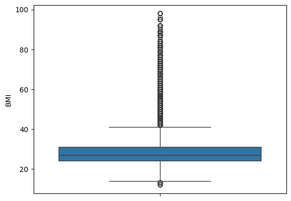

```python
sns.boxplot(df['BMI'])
```

```python
df['BMI'].quantile(0.99)
```

```
np.float64(50.0)
```

```python
df[df['BMI']<=df['BMI'].quantile(0.99)].shape
```

```
(251505, 22)
```

```python
df.drop(df[df['BMI']>df['BMI'].quantile(0.99)].index, inplace=True)
```

```python
df.shape
```

[output not shown]

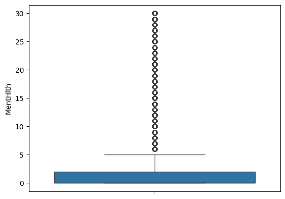

```python
sns.boxplot(df['MentHlth'])
```

```python
df['MentHlth'].quantile(0.9)
```

```
np.float64(10.0)
```

```python
df[df['MentHlth']>=df['MentHlth'].quantile(0.92)].shape
```

```
(23370, 22)
```

```python
df.drop(df[df['MentHlth']>=df['MentHlth'].quantile(0.92)].index, inplace=True)
```

```python
df.shape
```

```
(230310, 22)
```

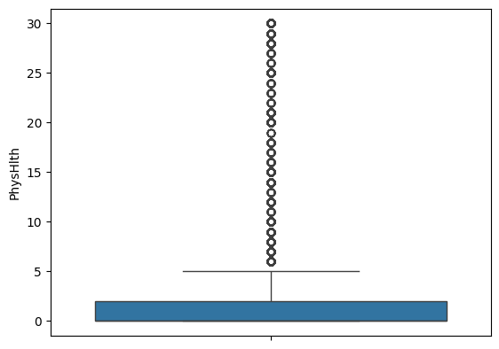

```python
sns.boxplot(df['PhysHlth'])
```

```python
df['PhysHlth'].quantile(0.93)
```

```
np.float64(20.0)
```

```python
df[df['PhysHlth']>=df['PhysHlth'].quantile(0.93)].shape
```

```
(16832, 22)
```

```python
df.drop(df[df['PhysHlth']>=df['PhysHlth'].quantile(0.93)].index, inplace=True)
```

```python
df.shape
```

```
(213478, 22)
```

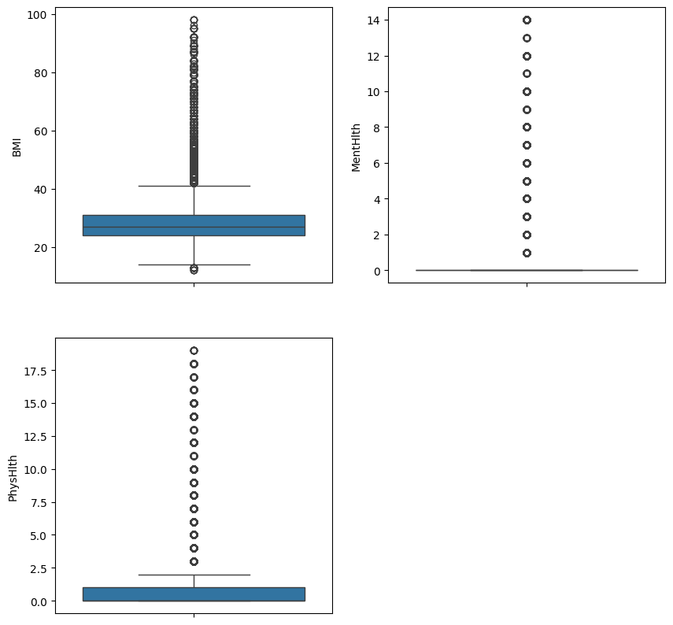

```python
plt.figure(figsize=(10,10))
plt.subplot(2,2,1)
sns.boxplot(df['BMI'])
plt.subplot(2,2,2)
sns.boxplot(df['MentHlth'])
plt.subplot(2,2,3)
sns.boxplot(df['PhysHlth'])
```

From observing the above box plots, there are some duplicate values in the data.

```python
df.duplicated().sum()
```

```
np.int64(23872)
```

```python
df.drop_duplicates(inplace=True)
```

```python
df.shape
```

```
(189606, 22)
```

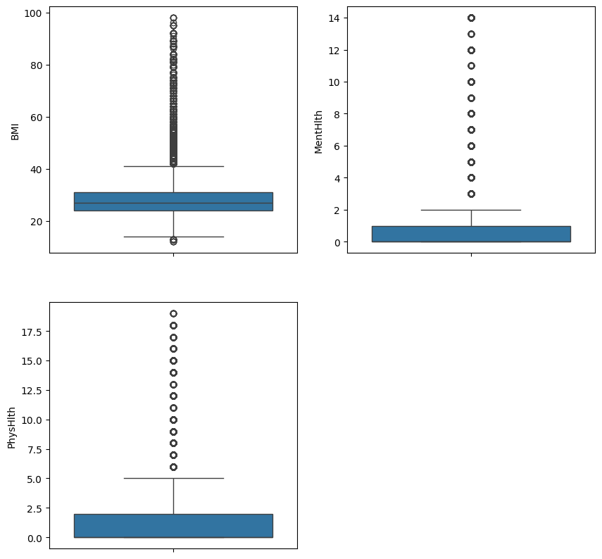

```python
plt.figure(figsize=(10,10))
plt.subplot(2,2,1)
sns.boxplot(df['BMI'])
plt.subplot(2,2,2)
sns.boxplot(df['MentHlth'])
plt.subplot(2,2,3)
sns.boxplot(df['PhysHlth'])
```

*By* removing the duplicates the outliers in the boxplots got reduced

### Exploratory Data Analysis

```python
df.info()
```

```
<class 'pandas.core.frame.DataFrame'>
Index: 189606 entries, 1 to 253679
Data columns (total 22 columns):
 #   Column                Non-Null Count   Dtype
---  ------                --------------   -----
 0   Diabetes_012          189606 non-null  float64
 1   HighBP                189606 non-null  float64
 2   HighChol              189606 non-null  float64
 3   CholCheck             189606 non-null  float64
 4   BMI                   189606 non-null  float64
 5   Smoker                189606 non-null  float64
 6   Stroke                189606 non-null  float64
 7   HeartDiseaseorAttack  189606 non-null  float64
 8   PhysActivity          189606 non-null  float64
 9   Fruits                189606 non-null  float64
 10  Veggies               189606 non-null  float64
 11  HvyAlcoholConsump     189606 non-null  float64
 12  AnyHealthcare         189606 non-null  float64
 13  NoDocbcCost           189606 non-null  float64
 14  GenHlth               189606 non-null  float64
 15  MentHlth              189606 non-null  float64
 16  PhysHlth              189606 non-null  float64
 17  DiffWalk              189606 non-null  float64
 18  Sex                   189606 non-null  float64
 19  Age                   189606 non-null  float64
 20  Education             189606 non-null  float64
 21  Income                189606 non-null  float64
dtypes: float64(22)
memory usage: 33.3 MB
```

```python
df['Diabetes_012'].value_counts()
```

[output not shown]

- **0 = no diabetes**
- **1 = prediabetes** -**2 = diabetes**

**HighBP**

- 0 = no high BP
- 1 = high BP

**HighChol**

- 0 = no high cholesterol
- 1 = high cholesterol

**CholCheck**

- 0 = no cholesterol check in 5 years
- 1 = yes cholesterol check in 5 years

**BMI** (Body Mass Index)

**Smoker** (Have you smoked at least 100 cigarettes in your entire life? [Note: 5 packs = 100 cigarettes])

- 0 = no
- 1 = yes

**Stroke** (Ever told) you had a stroke.

- 0 = no
- 1 = yes

**HeartDiseaseorAttack** ( coronary heart disease (CHD) or myocardial infarction (MI))

- 0 = no
- 1 = yes

**PhysActivity** (physical activity in past 30 days - not including job)

- 0 = no
- 1 = yes

**Fruits** (Consume Fruit 1 or more times per day)

- 0 = no
- 1 = yes

**Veggies** (Consume Vegetables 1 or more times per day)

- 0 = no
- 1 = yes

**HvyAlcoholConsump** (Heavy drinkers (adult men having more than 14 drinks per week and adult women having more than 7 drinks per week))

- 0 = no
- 1 = yes

**AnyHealthcare** (Have any kind of health care coverage, including health insurance, prepaid plans such as HMO, etc.)

- 0 = no
- 1 = yes

**NoDocbcCost** (Was there a time in the past 12 months when you needed to see a doctor but could not because of cost?)

- 0 = no
- 1 = yes

**GenHlth** (Would you say that in general your health is: scale 1-5)

- 1 = excellent
- 2 = very good
- 3 = good
- 4 = fair
- 5 = poor

**MentHlth**

- Now thinking about your mental health, which includes stress, depression, and problems with emotions, for how many days during the past 30 days was your mental health not good? scale 1-30 days

**PhysHlth**

- Now thinking about your physical health, which includes physical illness and injury, for how many days during the past 30 days was your physical health not good? scale 1-30 days

**DiffWalk** (Do you have serious difficulty walking or climbing stairs?)

- 0 = no
- 1 = yes

**Sex**

- 0 = female
- 1 = male

**Age** (13-level age category)

- 1 = 18-24
- 9 = 60-64
- 13 = 80 or older

**Education** (Education level (EDUCA see codebook) scale 1-6)

- 1 = Never attended school or only kindergarten
- 2 = Grades 1 through 8 (Elementary)
- 3 = Grades 9 through 11 (Some high school)
- 4 = Grade 12 or GED (High school graduate)
- 5 = College 1 year to 3 years (Some college or technical school)
- 6 = College 4 years or more (College graduate)

**Income** (Income scale 1-8)

- 1 = less than 10,000
- 5 = less than 35,000
- 8 = 75,000 or more

**Which factors or features are mainly causing the Diabetes?**

```python
df.head()
```

|  | Diabetes_012 | HighBP | HighChol | CholCheck | BMI | Smoker | Stroke | HeartDiseaseorAttack | PhysActivity | Fruits | Veggies | HvyAlcoholConsump | AnyHealthcare | NoDocbcCost | GenHlth | MentHlth | PhysHlth | DiffWalk | Sex | Age | Education | Income |
| --- | --- | --- | --- | --- | --- | --- | --- | --- | --- | --- | --- | --- | --- | --- | --- | --- | --- | --- | --- | --- | --- | --- |
| 1 | 0.0 | 0.0 | 0.0 | 0.0 | 25.0 | 1.0 | 0.0 | 0.0 | 1.0 | 0.0 | 0.0 | 0.0 | 0.0 | 1.0 | 3.0 | 0.0 | 0.0 | 0.0 | 0.0 | 7.0 | 6.0 | 1.0 |
| 3 | 0.0 | 1.0 | 0.0 | 1.0 | 27.0 | 0.0 | 0.0 | 0.0 | 1.0 | 1.0 | 1.0 | 0.0 | 1.0 | 0.0 | 2.0 | 0.0 | 0.0 | 0.0 | 0.0 | 11.0 | 3.0 | 6.0 |
| 4 | 0.0 | 1.0 | 1.0 | 1.0 | 24.0 | 0.0 | 0.0 | 0.0 | 1.0 | 1.0 | 1.0 | 0.0 | 1.0 | 0.0 | 2.0 | 3.0 | 0.0 | 0.0 | 0.0 | 11.0 | 5.0 | 4.0 |
| 5 | 0.0 | 1.0 | 1.0 | 1.0 | 25.0 | 1.0 | 0.0 | 0.0 | 1.0 | 1.0 | 1.0 | 0.0 | 1.0 | 0.0 | 2.0 | 0.0 | 2.0 | 0.0 | 1.0 | 10.0 | 6.0 | 8.0 |
| 6 | 0.0 | 1.0 | 0.0 | 1.0 | 30.0 | 1.0 | 0.0 | 0.0 | 0.0 | 0.0 | 0.0 | 0.0 | 1.0 | 0.0 | 3.0 | 0.0 | 14.0 | 0.0 | 0.0 | 9.0 | 6.0 | 7.0 |

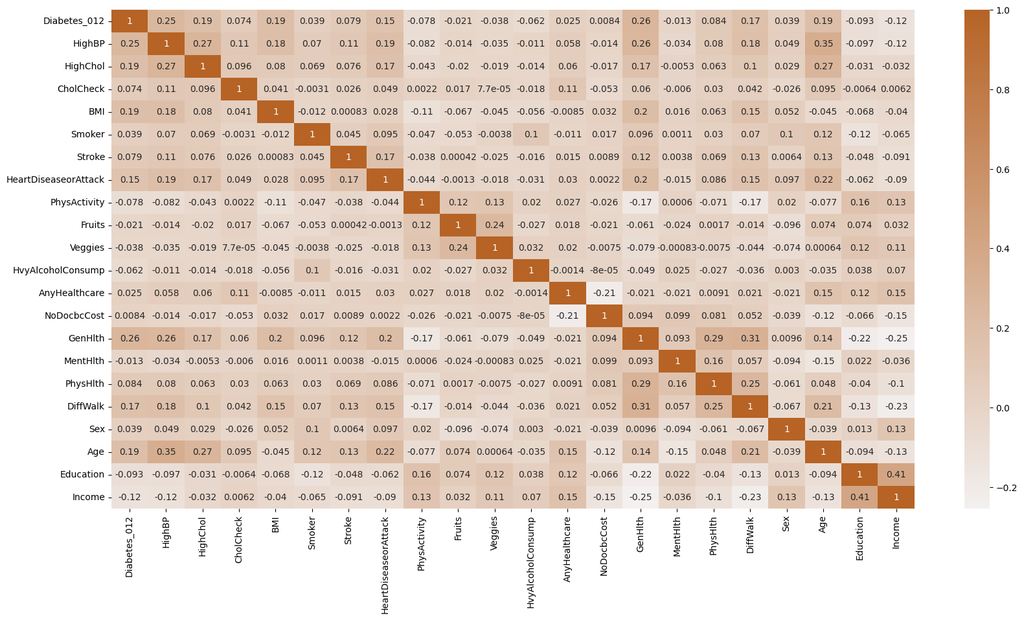

```python
plt.figure(figsize = (20,10))
sns.heatmap(df.corr(),annot=True , cmap =(sns.light_palette("xkcd:copper", as_cmap=True)))
```

**Observations**

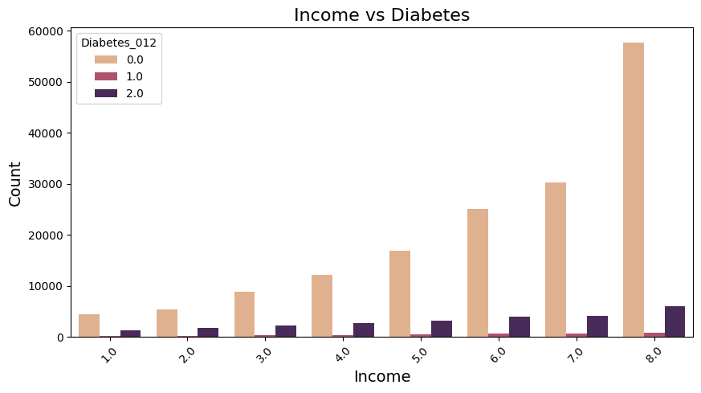

```python
plt.figure(figsize=(10, 5))
sns.countplot(x='Income', hue='Diabetes_012', data=df, palette="flare")
plt.title('Income vs Diabetes', fontsize=16)
plt.xlabel('Income', fontsize=14)
plt.ylabel('Count', fontsize=14)
plt.xticks(rotation=45)
plt.legend(title='Diabetes_012')
plt.show()
```

**Observation**

- From the graph, individuals with higher income have less chance of having diabetes. Since they have good general health, physical health and better access to the medical facilities.

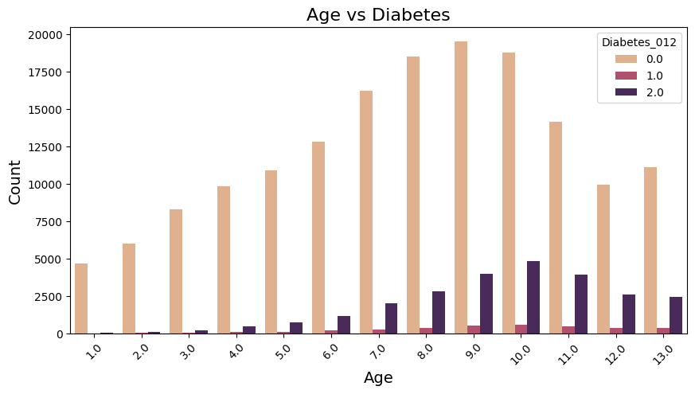

```python
plt.figure(figsize=(10, 5))
sns.countplot(x='Age', hue='Diabetes_012', data=df, palette="flare")
plt.title('Age vs Diabetes', fontsize=16)
plt.xlabel('Age', fontsize=14)
plt.ylabel('Count', fontsize=14)
plt.xticks(rotation=45)
plt.legend(title='Diabetes_012')
plt.show()
```

**Age Scale**

- 1 Age 18 to 24
- 2 Age 25 to 29
- 3 Age 30 to 34
- 4 Age 35 to 39
- 5 Age 40 to 44
- 6 Age 45 to 49
- 7 Age 50 to 54
- 8 Age 55 to 59
- 9 Age 60 to 64
- 10 Age 65 to 69
- 11 Age 70 to 74
- 12 Age 75 to 79
- 13 Age 80 or older

**Obeservation**

- Age group between 55 to 74 has higher number individuals having Diabetes.

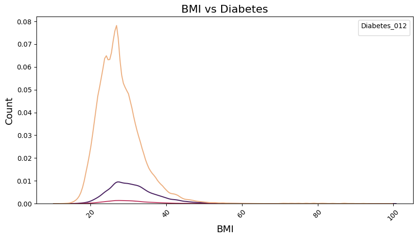

```python
plt.figure(figsize=(10, 5))
sns.kdeplot(x='BMI', hue='Diabetes_012', data=df, palette="flare")
plt.title('BMI vs Diabetes', fontsize=16)
plt.xlabel('BMI', fontsize=14)
plt.ylabel('Count', fontsize=14)
plt.xticks(rotation=45)
plt.legend(title='Diabetes_012')
plt.show()
```

People with Body Mass Index between 20 to 40 having Diabetes.

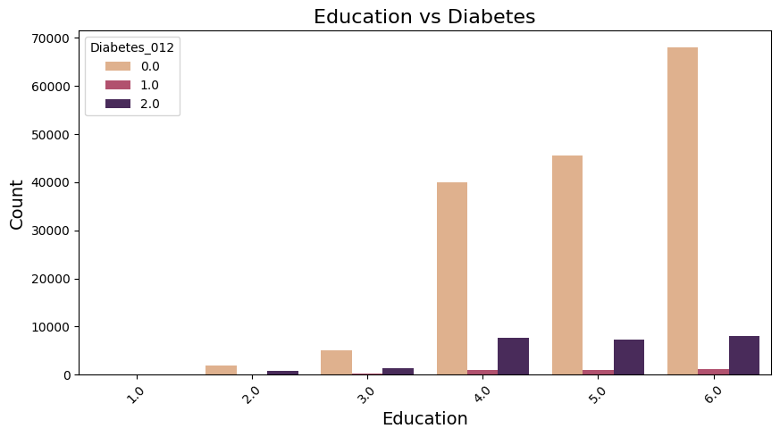

```python
plt.figure(figsize=(10, 5))
sns.countplot(x='Education', hue='Diabetes_012', data=df, palette="flare")
plt.title('Education vs Diabetes', fontsize=16)
plt.xlabel('Education', fontsize=14)
plt.ylabel('Count', fontsize=14)
plt.xticks(rotation=45)
plt.legend(title='Diabetes_012')
plt.show()
```

```python
df['Education'].value_counts()
```

```
Education
6.0    77423
5.0    53855
4.0    48754
3.0     6662
2.0     2800
1.0      112
Name: count, dtype: int64
```

Since the data is imbalanced we cannot confirm that People with low education are not diabetic.

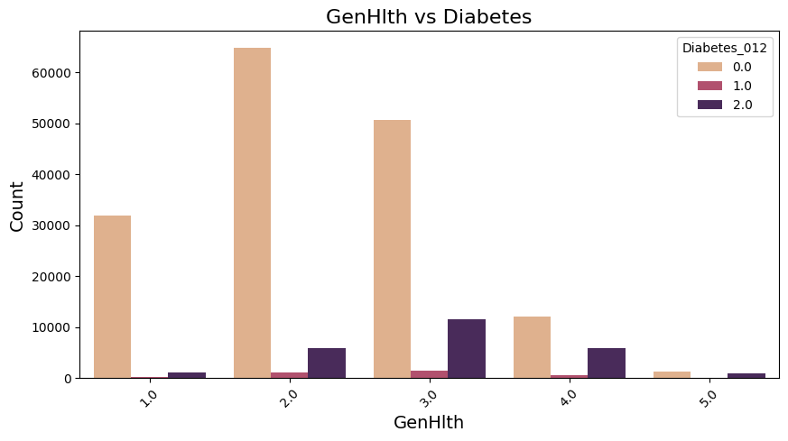

```python
plt.figure(figsize=(10, 5))
sns.countplot(x='GenHlth', hue='Diabetes_012', data=df, palette="flare")
plt.title('GenHlth vs Diabetes', fontsize=16)
plt.xlabel('GenHlth', fontsize=14)
plt.ylabel('Count', fontsize=14)
plt.xticks(rotation=45)
plt.legend(title='Diabetes_012')
plt.show()
```

People with medium General Health are the most Diabetic.

## Model selection & Training

```python
x = df.drop('Diabetes_012', axis=1)
y = df['Diabetes_012']
```

```python
x_train, x_test, y_train, y_test = train_test_split(x, y, test_size=0.2, random_state=42)
```

```python
y.value_counts()
```

```
Diabetes_012
0.0    160684
2.0     25363
1.0      3559
Name: count, dtype: int64
```

```python
from imblearn.over_sampling import SMOTE
smote = SMOTE(sampling_strategy='auto',random_state=42)
x_train, y_train = smote.fit_resample(x_train,y_train)
x_test, y_test = smote.fit_resample(x_test,y_test)
```

```python
x_unseen = x_train.sample(frac=0.2,random_state=42)
y_unseen = y_train[x_unseen.index]
x_train.drop(x_unseen.index,inplace=True)
y_train.drop(y_unseen.index,inplace=True)
```

```python
y_train.value_counts()
```

```
Diabetes_012
2.0    102865
0.0    102825
1.0    102792
Name: count, dtype: int64
```

```python
y_test.value_counts()
```

```
Diabetes_012
2.0    32150
0.0    32150
1.0    32150
Name: count, dtype: int64
```

```python
dt_model = DecisionTreeClassifier()
dt_model.fit(x_train,y_train)
dt_y_pred = dt_model.predict(x_test)
dt_y_pred_train = dt_model.predict(x_train)
print("Test Scores ---")
print(classification_report(y_test,dt_y_pred))
print("-"*20)
print("Train Scores ---")
print(classification_report(y_train,dt_y_pred_train))
```

```
Test Scores ---
              precision    recall  f1-score   support

         0.0       0.81      0.85      0.83     32150
         1.0       0.59      0.31      0.41     32150
         2.0       0.46      0.66      0.54     32150

    accuracy                           0.60     96450
   macro avg       0.62      0.60      0.59     96450
weighted avg       0.62      0.60      0.59     96450

--------------------
Train Scores ---
              precision    recall  f1-score   support

         0.0       0.99      1.00      1.00    102825
         1.0       1.00      1.00      1.00    102792
         2.0       1.00      0.99      1.00    102865

    accuracy                           1.00    308482
   macro avg       1.00      1.00      1.00    308482
weighted avg       1.00      1.00      1.00    308482
```

Decision Tree model is overfitted.

## Hyperparameter Tuning

```python
from sklearn.model_selection import RandomizedSearchCV
dt = DecisionTreeClassifier()
param_grid = {
    'criterion': ['gini', 'entropy'],
    'max_depth': [5, 10, 15, 20],
    'min_samples_split': [2, 5, 10, 15, 20],
    'min_samples_leaf': [1, 2, 5, 10],
    'max_features': ['sqrt', 'log2', None]
}

gcv = RandomizedSearchCV(dt,param_grid, scoring='f1',n_jobs=-1,cv=3)
gcv.fit(x_train,y_train)
gcv.best_params_
```

```
{'min_samples_split': 10,
 'min_samples_leaf': 10,
 'max_features': 'log2',
 'max_depth': 5,
 'criterion': 'entropy'}
```

```python
dt_model1 = DecisionTreeClassifier(min_samples_split= 2,
 min_samples_leaf= 2,
 max_features= None,
 max_depth= 10,
 criterion= 'gini')
dt_model1.fit(x_train,y_train)
dt_y_pred = dt_model1.predict(x_test)
dt_y_pred_train = dt_model1.predict(x_train)
print("Test Scores ---")
print(classification_report(y_test,dt_y_pred))
print("-"*20)
print("Train Scores ---")
print(classification_report(y_train,dt_y_pred_train))
```

```
Test Scores ---
              precision    recall  f1-score   support

         0.0       0.82      0.85      0.83     32150
         1.0       0.61      0.66      0.64     32150
         2.0       0.51      0.44      0.47     32150

    accuracy                           0.65     96450
   macro avg       0.64      0.65      0.65     96450
weighted avg       0.64      0.65      0.65     96450

--------------------
Train Scores ---
              precision    recall  f1-score   support

         0.0       0.78      0.85      0.81    102825
         1.0       0.69      0.72      0.71    102792
         2.0       0.60      0.52      0.56    102865

    accuracy                           0.70    308482
   macro avg       0.69      0.70      0.69    308482
weighted avg       0.69      0.70      0.69    308482
```

Model is not overfitted or underfitted but need to improve the scores.

## Feature Engineering.

- Considering only Important features

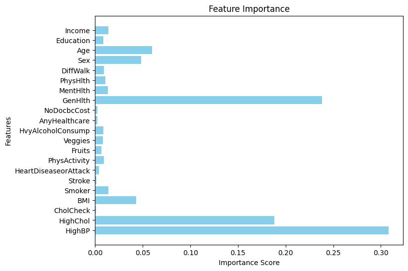

```python
importance = dt_model1.feature_importances_
features = x_train.columns
plt.figure(figsize=(8, 6))
plt.barh(features, importance, color='skyblue')
plt.xlabel('Importance Score')
plt.ylabel('Features')
plt.title('Feature Importance')
plt.show()
```

```python
features = dict(zip(features,importance))
features
imp_features = [key for key in features.keys() if features[key] > 0.01]
imp_features
```

```
['HighBP',
 'HighChol',
 'BMI',
 'Smoker',
 'GenHlth',
 'MentHlth',
 'PhysHlth',
 'Sex',
 'Age',
 'Income']
```

```python
x_train_re = x_train[imp_features]
x_test_re = x_test[imp_features]
```

```python
dt_model2 = DecisionTreeClassifier(min_samples_split= 15,
 min_samples_leaf= 1,
 max_features= 'log2',
 max_depth= 5,
 criterion= 'gini')
dt_model2.fit(x_train_re,y_train)
dt_y_pred = dt_model2.predict(x_test_re)
dt_y_pred_train = dt_model2.predict(x_train_re)
print("Test Scores ---")
print(classification_report(y_test,dt_y_pred))
print("-"*20)
print("Train Scores ---")
print(classification_report(y_train,dt_y_pred_train))
```

```
Test Scores ---
              precision    recall  f1-score   support

         0.0       0.72      0.71      0.71     32150
         1.0       0.65      0.39      0.49     32150
         2.0       0.46      0.64      0.53     32150

    accuracy                           0.58     96450
   macro avg       0.61      0.58      0.58     96450
weighted avg       0.61      0.58      0.58     96450

--------------------
Train Scores ---
              precision    recall  f1-score   support

         0.0       0.67      0.71      0.69    102825
         1.0       0.66      0.36      0.47    102792
         2.0       0.47      0.65      0.54    102865

    accuracy                           0.57    308482
   macro avg       0.60      0.57      0.57    308482
weighted avg       0.60      0.57      0.57    308482
```

Decision Tree Model is producing decent Scores after considering only important features based on feature importance. But need to check with the unseen data

## Testing with unseen data

```python
dt_y_pred = dt_model2.predict(x_unseen[imp_features])
dt_y_pred_train = dt_model2.predict(x_train_re)
print("Test Scores ---")
print(classification_report(y_unseen,dt_y_pred))
```

```
Test Scores ---
              precision    recall  f1-score   support

         0.0       0.67      0.72      0.69     25709
         1.0       0.66      0.36      0.46     25742
         2.0       0.47      0.66      0.55     25669

    accuracy                           0.58     77120
   macro avg       0.60      0.58      0.57     77120
weighted avg       0.60      0.58      0.57     77120
```

- Decision Tree Classifier model is giving good scores. But we need to try the other models.

### RandomForestClassifier

```python
rfc = RandomForestClassifier(n_estimators=200,max_depth=7)
rfc.fit(x_train,y_train)
rfc_y_pred = rfc.predict(x_test)
rfc_y_pred_train = rfc.predict(x_train)
print("Test Scores ---")
print(classification_report(y_test,rfc_y_pred))
print("-"*20)
print("Train Scores ---")
print(classification_report(y_train,rfc_y_pred_train))
```

```
Test Scores ---
              precision    recall  f1-score   support

         0.0       0.81      0.82      0.82     32150
         1.0       0.64      0.67      0.65     32150
         2.0       0.54      0.50      0.52     32150

    accuracy                           0.67     96450
   macro avg       0.66      0.67      0.66     96450
weighted avg       0.66      0.67      0.66     96450

--------------------
Train Scores ---
              precision    recall  f1-score   support

         0.0       0.77      0.83      0.80    102825
         1.0       0.68      0.64      0.66    102792
         2.0       0.56      0.55      0.55    102865

    accuracy                           0.67    308482
   macro avg       0.67      0.67      0.67    308482
weighted avg       0.67      0.67      0.67    308482
```

```python
y_pred = rfc.predict(x_unseen)
print(classification_report(y_unseen,y_pred))
```

```
              precision    recall  f1-score   support

         0.0       0.77      0.82      0.80     25709
         1.0       0.68      0.64      0.66     25742
         2.0       0.56      0.55      0.55     25669

    accuracy                           0.67     77120
   macro avg       0.67      0.67      0.67     77120
weighted avg       0.67      0.67      0.67     77120
```

RandomForestClassifier produced the best results among the trained models.

### Saving the model

```python
import joblib
joblib.dump(rfc,'Diabetes_model.pkl')
print("Model saved")
```

```
Model saved
```

## Conclusion

```
>This proposed machine learning pipeline effectively predicts diabetes risk from lifestyle, medical history, and demographic data. By leveraging multiple models and feature importance details, it provides a data-driven approach to a pressing public health issue.
>Even though the solution has good predictive power, data imbalance, explainability, and generalization issues must be addressed for the best outcome. Employing SHAP values, cutting-edge resampling techniques, and regular model updating can boost reliability even further.
>From a business perspective, these findings justify evidence-based policymaking, early detection of disease, cost-saving interventions, and targeted community health interventions. Maximum real-world usefulness can be attained by applying this model in healthcare software or public health dashboards.
>Proactive diabetes prevention and management can be the outcome of this solution with ongoing refinement and integration with healthcare systems.
```

## Strengths

[output not shown]

## Limitations & Challenges

```
>Feature Engineering Scope The data set can be supplemented with external health records, measured wearable data, etc.
>Imbalanced Data Handling Where diabetes cases are under sampled, resampling techniques (SMOTE) can improve prediction.
>Complexity of Complex Model Explainability Random Forest and Gradient Boosting are harder to interpret than Decision Trees.Data Quality and            >Missing Values :Missing or inaccurate data can impact model performance; robust imputation techniques or alternative data sources may be necessary.
>Applying to Various Groups The model might not generalize effectively to varied populations or unseen populations, necessitating retraining from time to time using new datasets.
```

## Business Implications of the Findings

```
>Public Health Agencies Assists in evidence-based policy-making and focused interventions.
>Healthcare Providers Facilitates early detection and personalized treatment plans.
>For Employers & Insurers Helps in health risk assessment and cost-saving measures.
>Pharmaceutical & Medical Research Facilitates drug development and preventive care efforts by defining high-risk groups and their most critical health indicators.
>Community Health Programs Coordinates special wellness initiatives to promote physical activity and healthy eating habits among at-risk populations.
```

## Data-Driven Recommendations

```
>Feature Importance Insights Wherever possible, utilize SHAP or tree-based model feature importance to choose top predictors.
>Enhancing Model Performance Try more sophisticated methods such as XGBoost or deep learning.
>Deployment Strategy Think about incorporating the model into healthcare software or public health dashboards.
>Handling Class Imbalance If the data is imbalanced (e.g., diabetic cases are fewer), try using techniques such as SMOTE (Synthetic Minority Over-sampling Technique) or weighted loss functions to enhance model performance.
>Real-Time Monitoring & Continuous Learning Implement a feedback cycle where the model is continuously revised with new data to learn from emerging health trends and improve prediction accuracy over time.
```

## Most informative Features of the model

[output not shown]